# Sesión 3

# ESTADISTICA PARA EL ANALISIS POLITICO II

- Profesor: [Dr. José Manuel Magallanes, Ph.D.](http://www.pucp.edu.pe/profesor/jose-manuel-magallanes/)
  - Profesor del Departamento de Ciencias Sociales, Sección de Ciencia Política y Gobierno.
  - [Oficina 105](https://goo.gl/maps/xuGeG6o9di1i1y5m6) - Edificio CISEPA / ECONOMIA / CCSS
  - Telefono: (51) 1 - 6262000 anexo 4302
  - Correo Electrónico: jmagallanes@pucp.edu.pe

## Regresión No Lineal - Modelo Binomial Logístico

La data de este material está basada en el trabajo de [Cowles y Davis](https://onlinelibrary.wiley.com/doi/abs/10.1111/j.2044-8309.1987.tb00769.x). Los datos y la metadata están disponibles [aqui](http://vincentarelbundock.github.io/Rdatasets/datasets.html).

Por facilidad puedes verlos aqui en GoogleDocs:

[interactive chart not shown]

Esta investigación desea saber si **el ofrecerse como voluntario está relaciondo con el sexo de la persona, su nivel de neuroticismo y su nivel de extraversión**.

# Parte 1. Preparación de datos

## 1. Datos a utilizar

- Leemos los datos desde Google.

```r
link="https://docs.google.com/spreadsheets/d/e/2PACX-1vTnBAuw8v3PgGMivOBI9tFfGjVrZsVnteUF2y44HjZneYoajlrb9k61kWN300Q-n1q04iy8_nsB68n_/pub?gid=1431542138&single=true&output=csv"
vol=read.csv(link, stringsAsFactors = F)
```

- Verificamos qué tipo de datos tenemos:

```r
str(vol)
```

```
## 'data.frame':    1421 obs. of  4 variables:
##  $ neuroticism : int  16 8 5 8 9 6 8 12 15 18 ...
##  $ extraversion: int  13 14 16 20 19 15 10 11 16 7 ...
##  $ sex         : chr  "female" "male" "male" "female" ...
##  $ volunteer   : chr  "no" "no" "no" "no" ...
```

## 2. Pre procesamiento

Hay dos columnas que deben ser convertidas a categóricas.

```r
vol[,c(3,4)]=lapply(vol[,c(3,4)],as.factor)
```

## 3. Exploración

- Una vez formateada, exploremos la data estadísticamente

```r
summary(vol)
```

```
##   neuroticism     extraversion       sex      volunteer
##  Min.   : 0.00   Min.   : 2.00   female:780   no :824
##  1st Qu.: 8.00   1st Qu.:10.00   male  :641   yes:597
##  Median :11.00   Median :13.00
##  Mean   :11.47   Mean   :12.37
##  3rd Qu.:15.00   3rd Qu.:15.00
##  Max.   :24.00   Max.   :23.00
```

**NO OLVIDAR**: * Las categóricas siempre se almacenan internamente como números, y éstos se asignarán por defecto en orden alfabético. De ahi que el primer nivel de cada categórica se conoce como la **categoría de referencia**.

- Hay funciones que requieren usar los factores como números, en ese sentido, asegúrate que el orden de las categóricas sea el correcto: que el evento de interés sea el mayor valor (en esta caso voluntario):

```r
# original
table(vol$volunteer)
```

```
##
##  no yes
## 824 597
```

```r
# como numero
table(as.numeric(vol$volunteer))
```

```
##
##   1   2
## 824 597
```

# Parte 2. Análisis bivariado

## 1. Usando la tabla de contingencia

Queremos saber si ser mujer está relacionado con ser voluntario en proyectos de investigación. Al ser ambas categóricas, y ser la hipótesis asimétrica o direccional, preparemos una tabla de contingencia que muestre ello:

```r
dep=vol$volunteer # a la fila
ind=vol$sex # a la columna

volsexTable=table(dep,ind,dnn = c('volunteer','sex'))

### suma por columna
addmargins(volsexTable,margin = 1)
```

```
##          sex
## volunteer female male
##       no     431  393
##       yes    349  248
##       Sum    780  641
```

Saber si ser mujer está relacionado con ser voluntario implica saber dos cosas más:

- Si elijo una mujer al azar, qué probabilidad se tiene que ésta sea voluntaria.
- Cómo comparo el “voluntarismo” de la mujer con la del hombre.

## 2. Probabilidades y ODDS

#### A. Caso de la mujer:

- La **probabilidad** que una mujer elegida al azar sea voluntaria es la división del ser voluntaria entre el total de mujeres:

```r
probMV=volsexTable[2,1]/sum(volsexTable[,1])
probMV
```

```
## [1] 0.4474359
```

La probabilidad es un valor que va de 0 a 1. Recuperemos lo valores de la tabla de contingencia:

```r
library(MASS)
fractions(probMV)
```

```
## [1] 349/780
```

- Representemos el **odds** que sea voluntaria: la división entre ser o no ser voluntaria:

```r
volsexTable[2,1]/volsexTable[1,1]
```

```
## [1] 0.8097448
```

Que se origina de:

```r
fractions(volsexTable[2,1]/volsexTable[1,1])
```

```
## [1] 349/431
```

El *odds* suele representarse además como la razón entre dos probabilidades: la probabilidad que ocurra un evento dividido por la probabilidad que NO ocurra ese evento:

```r
OddsMV=probMV/(1-probMV)
OddsMV
```

```
## [1] 0.8097448
```

#### B. Caso del hombre:

- Probabilidad que un hombre elegido al azar sea voluntario:

```r
probHV=volsexTable[2,2]/sum(volsexTable[,2])
probHV
```

```
## [1] 0.3868955
```

O…

```r
fractions(probHV)
```

```
## [1] 248/641
```

- El odds que el hombre sea voluntario:

```r
OddsHV=probHV/(1-probHV)
OddsHV
```

```
## [1] 0.6310433
```

O…

```r
fractions(OddsHV)
```

```
## [1] 248/393
```

#### C. Comparando Mujer y Hombre:

Hasta aquí ya sabemos cuál odds ha salido mayor. Eso es información clara. Para precisar esa información, podemos dividir los odds, lo que nos da el **odds ratio**, que en este caso nos dirá *qué diferencia produce el sexo en el voluntariado*:

```r
#Mujer/Hombre
(OR_MH=OddsMV/OddsHV)
```

```
## [1] 1.283184
```

Con ese valor, ya sabemos que el odds de ser mujer es 0.28 por encima del odds del hombre. El odds ratio (OR) puede ir de 0 a infinito. Un OR de 1 implica que no hay diferencias.

Si quieres verlo como fracción:

```r
fractions(OddsMV/OddsHV)
```

```
## [1] 137157/106888
```

Esto informa que la cantidad de mujeres que encontrarias de voluntarias ante una cantidad de hombres voluntarios.

#### D. Porcentajes y gráficas

Veamos la tabla de contingencia con los porcentajes por columna:

```r
prop.table(volsexTable,margin = 2)
```

```
##          sex
## volunteer    female      male
##       no  0.5525641 0.6131045
##       yes 0.4474359 0.3868955
```

Grafiquemoslo:

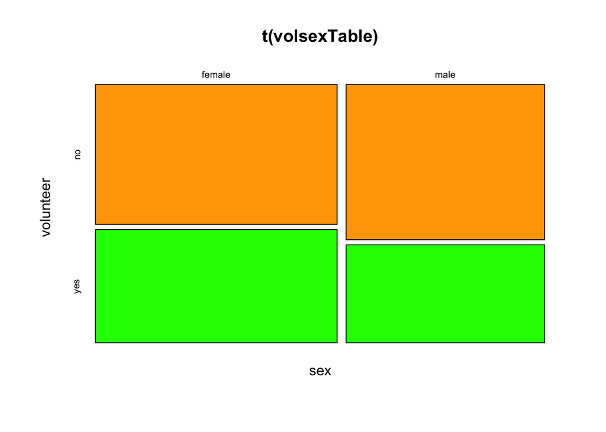

```r
mosaicplot( t(volsexTable),col = c("orange", "green"))
```

A pesar de la diferencia, ¿será ésta significativa?

# Parte 3. Regresión Logística

La regresión logística modela el comportamiento de la probabilidad del evento de interés:

$${log}(\frac{{p}}{{1 – p}}) = \beta_0 + \beta_ix_i$$

La parte izquierda representa esa probabilidad pero en términos del odds. La parte derecha de la ecuación es igual a la ecuación de una recta, pero estamos modelando al logaritmo del odds. Veamos cómo calcularla en R:

```r
### semilla

set.seed(2019)

### primer modelo:
#data como subset
vars1=vol[,c("volunteer","sex")]

#regresion
rlog1=glm(volunteer~., data=vars1,family = binomial)

#resultado clásico:
summary(rlog1)
```

```
##
## Call:
## glm(formula = volunteer ~ ., family = binomial, data = vars1)
##
## Deviance Residuals:
##     Min       1Q   Median       3Q      Max
## -1.0892  -1.0892  -0.9892   1.2682   1.3781
##
## Coefficients:
##             Estimate Std. Error z value Pr(>|z|)
## (Intercept) -0.21104    0.07201  -2.931  0.00338 **
## sexmale     -0.24934    0.10845  -2.299  0.02150 *
## ---
## Signif. codes:  0 '***' 0.001 '**' 0.01 '*' 0.05 '.' 0.1 ' ' 1
##
## (Dispersion parameter for binomial family taken to be 1)
##
##     Null deviance: 1933.5  on 1420  degrees of freedom
## Residual deviance: 1928.2  on 1419  degrees of freedom
## AIC: 1932.2
##
## Number of Fisher Scoring iterations: 4
```

Veamos ahora el resultado con mejor formato:

````r
# recuerda poner: ```{r, results='asis'}
library(stargazer)
#resultado
stargazer(rlog1,type="html")
````

|  | *Dependent variable:* |
| --- | --- |
|  | volunteer |
| sexmale | -0.249** |
|  | (0.108) |
| Constant | -0.211*** |
|  | (0.072) |
| Observations | 1,421 |
| Log Likelihood | -964.101 |
| Akaike Inf. Crit. | 1,932.202 |
| *Note:* | p<0.1; p<0.05; p<0.01 |

Los coeficientes, como se vió en la ecuación anterior, están modelando al logaritmo del odds de ser voluntario.

El resultado anterior ha usado a mujer como *referencia*: nos informa cuánto afecta al log odds de ser voluntario el ser hombre en comparación con ser mujer (la referencia). Ahora sabes que ser hombre disminuye la probabilidad de ser voluntario. Ajustemos la referencia para ver el efecto de mujer:

```r
# nueva referencia
vol$sex=relevel(vol$sex,ref = "male")

# rehago subset
vars1=vol[,c("volunteer","sex")]

rlog1=glm(volunteer~., data=vars1,family = binomial)
```

Los resultados van a continuación:

```r
#resultado
stargazer(rlog1,type="html")
```

|  | *Dependent variable:* |
| --- | --- |
|  | volunteer |
| sexfemale | 0.249** |
|  | (0.108) |
| Constant | -0.460*** |
|  | (0.081) |
| Observations | 1,421 |
| Log Likelihood | -964.101 |
| Akaike Inf. Crit. | 1,932.202 |
| *Note:* | p<0.1; p<0.05; p<0.01 |

Vemos que sexo tiene efecto, y el símbolo del coeficiente propone que el efecto es positivo. Ese valor, como modela a un logaritmo, no es fácil de interpretar. Pero, si le aplicas exponencial, hallarás un valor conocido:

```r
sexF=coef(rlog1)["sexfemale"]
exp(sexF)
```

```
## sexfemale
##  1.283184
```

Ahora sabemos que el efecto de sexo es significativo gracias a la regresión logística, algo que no sabíamos con las tablas de contingencia.

Además, con la regresión logística podemos tener predictores numéricos, lo que escapa de la utilidad de las tablas de contingencia:

```r
vars2=vol[,c("volunteer","sex","neuroticism")]
rlog2=glm(volunteer~., data=vars2,family = binomial)
```

```r
vars3=vol[,c("volunteer","sex","neuroticism","extraversion")]
rlog3=glm(volunteer~., data=vars3,family = binomial)
```

Veamos todos:

```r
library(stargazer)

stargazer(rlog1,rlog2,rlog3,type = "html",no.space = F,digits =3,digit.separator="")
```

|  | *Dependent variable:* |  |  |
| --- | --- | --- | --- |
|  | volunteer |  |  |
|  | (1) | (2) | (3) |
| sexfemale | 0.249** | 0.248** | 0.235** |
|  | (0.108) | (0.110) | (0.111) |
| neuroticism |  | 0.001 | 0.006 |
|  |  | (0.011) | (0.011) |
| extraversion |  |  | 0.066*** |
|  |  |  | (0.014) |
| Constant | -0.460*** | -0.467*** | -1.352*** |
|  | (0.081) | (0.143) | (0.240) |
| Observations | 1421 | 1421 | 1421 |
| Log Likelihood | -964.101 | -964.099 | -953.031 |
| Akaike Inf. Crit. | 1932.202 | 1934.199 | 1914.061 |
| *Note:* | p<0.1; p<0.05; p<0.01 |  |  |

## 1. Comparando modelos

Las tres regresiones presentan valores diferentes del criterio de información de Akaike (AIC), se considera que un modelo es mejor si tiene un AIC menor a los demás. Esto sugiere qu el tercer modelo es el mejor y el segundo el peor. Como los valores del AIC están muy cercanos confirmemos usando el test de razón de verosimilitud (likelihood ratio test -LRT):

```r
library(lmtest)

lrtest(rlog1,rlog2, rlog3)
```

```
## Likelihood ratio test
##
## Model 1: volunteer ~ sex
## Model 2: volunteer ~ sex + neuroticism
## Model 3: volunteer ~ sex + neuroticism + extraversion
##   #Df  LogLik Df   Chisq Pr(>Chisq)
## 1   2 -964.10
## 2   3 -964.10  1  0.0034     0.9537
## 3   4 -953.03  1 22.1372  2.538e-06 ***
## ---
## Signif. codes:  0 '***' 0.001 '**' 0.01 '*' 0.05 '.' 0.1 ' ' 1
```

O alternativamente:

```r
library(pander)
pander(lrtest(rlog1,rlog2, rlog3),caption = "LRT para los tres modelos")
```

LRT para los tres modelos

| #Df | LogLik | Df | Chisq | Pr(>Chisq) |
| --- | --- | --- | --- | --- |
| 2 | -964.1 | NA | NA | NA |
| 3 | -964.1 | 1 | 0.003376 | 0.9537 |
| 4 | -953 | 1 | 22.14 | 2.538e-06 |

Como vemos, pasar del modelo 1 al modelo 2 es no significativo (probabilidad es mayor a 0.05), por lo que no se rechaza la hipotesis nula de igualdad de modelos. Pero sí es significativo pasar del modelo 2 al modelo 3.

## 2. Efectos Marginales

Recuerdese que aún NO sabemos cuando afecta cada variable la probabilidad de ser voluntario en promedio. Para ello pedimos efectos marginales.

```r
# interpracion usando marginal effects:
library(margins)
#
(model = margins(rlog3))
```

```
## Average marginal effects
```

```
## glm(formula = volunteer ~ ., family = binomial, data = vars3)
```

```
##  neuroticism extraversion sexfemale
##      0.00152      0.01585   0.05623
```

Esto sí indica cuanto afecta cada variable la probabilidad de ser voluntario.

Para graficar veamos un resumen:

```r
(margins=summary(model))
```

```
##        factor    AME     SE      z      p   lower  upper
##  extraversion 0.0158 0.0033 4.7929 0.0000  0.0094 0.0223
##   neuroticism 0.0015 0.0027 0.5604 0.5752 -0.0038 0.0068
##     sexfemale 0.0562 0.0265 2.1229 0.0338  0.0043 0.1081
```

Luego, aqui vemos efecto:

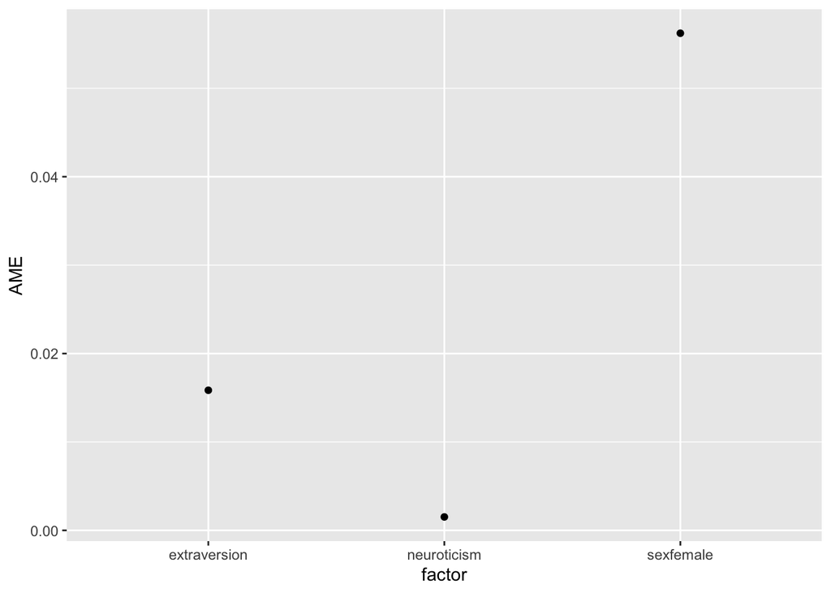

```r
library(ggplot2)
base= ggplot(margins,aes(x=factor, y=AME)) + geom_point()
base
```

Aqui el efecto y su intervalo de confianza:

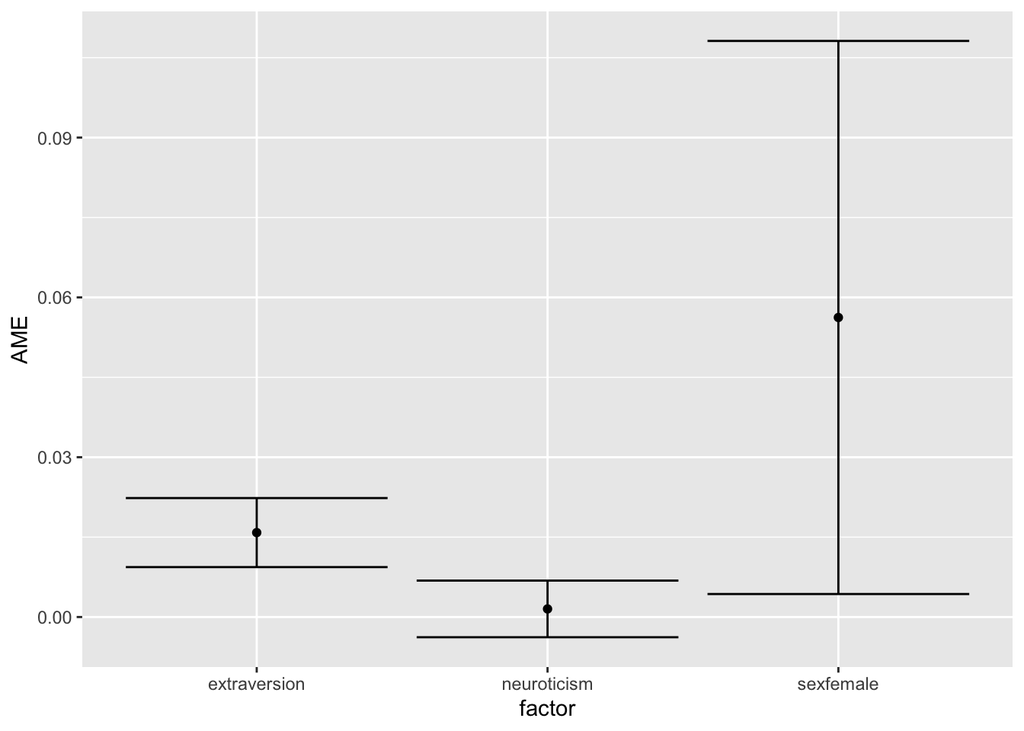

```r
base +  geom_errorbar(aes(ymin=lower, ymax=upper))
```

al INICIO